# Recap

In the first lesson we learned to interpret the outermost layer of the Bitcoin Protocol onion: the [message structure](https://en.bitcoin.it/wiki/Protocol_documentation#Message_structure). We learned to send a `version` message to Bitcoin Network peers and listen for their `version` response. We learned to read this response and check that the correct `magic` bytes came at the beginning of the message; to interpret which of the 27 `command` types the message is; to read `payload` data associated with the command and the check the payload with a `checksum` given to us by our remote peer;

In the second lesson we learned to peel another layer or two of the onion. We learned to read the [payload](https://en.bitcoin.it/wiki/Protocol_documentation#version) of `version` messages. Along the way we had to figure out how to interpret all the sub-structures of the data, such as variable-length strings", variable-length integers, network addresses, `services` bitfields, Unix timestamps, and big-endian encoded port numbers.

We've come a long way, but we still have a long way to go.

# Getting To Know Each Other

Now that we can talk to our peers, let's be friendly neighbors and introduce ourself.

In this lesson we will connect to the nearl 10,000 Bitcoin Network peers that operate out in the open. We'll send each a `version` message and we'll record for their responses. Our first attempts at this will be far too slow and we will learn about "concurrent programming" -- a technique that frees our program to work on many things at once, in our case talking to Bitcoin Network peers.

Let's get started!

# Bitnodes

The first thing we did in the first lesson was to pull up [this website](https://bitnodes.earn.com/nodes/) and look for the IP address of some other node to talk to.

Now we're going to write some Python code to do this for us.

bitnodes.earn.com offers [a free, unauthenticated API](https://bitnodes.earn.com/api/#list-nodes) to help us do this. You've probably heard this word before -- API -- and you probably don't know exactly what it means. The acronym [API](https://en.wikipedia.org/wiki/Application_programming_interface) stands for "Application Programming Interface". An "Application Programming Interface" is a description of how a programmer can interact with a piece of software. For example, Python has an API for converting `bytes` to `int`s: [int.from_bytes(bytes, byteorder, *, signed=False)](https://docs.python.org/3/library/stdtypes.html#int.from_bytes). Python defines this exact function allowing programmers to accomplish this exact operation. There are multiple different "implementations" of python -- CPython, PyPy, MicroPython etc -- and they all implement this same API.

So that's the original meaning of the term "application programming interface". But it's most frequently used describe this sort of thing in a specific domain: web programming. Please read this [explainer](https://medium.freecodecamp.org/what-is-an-api-in-english-please-b880a3214a82) of this more narrow definition of the term. The [earn.com API](https://bitnodes.earn.com/api/) is one such example of "API" in this sense of the word.

The earn.com API is free and also "unauthenticated" which means we don't have to present any kind of credential in order to use this -- stock market data APIs, for one, aren't so kind!

To "exercise" this API we need to send a GET http request. This is the same sort of request that your browser sense every time you load a webpage. It just fetches data.

### cURL: A Terminal Utility

Go to your command line and type this in:

```
$ curl -H "Accept: application/json; indent=4" https://bitnodes.earn.com/api/v1/snapshots/latest/
```

(If you get any error you probably need to install the cURL program. Google it!)

This should spit a huge amoutn of "JSON" out onto your terminal. This is a complete list of all Bitcoin Network nodes which earn.com has been able to find.

### Requests: A Python Library

This is great, but we need to find a way to do this from Python. This is where the `requests` library comes in. Watch [this video](https://www.youtube.com/watch?v=_8HPCToXdAk) to learn how to use `requests`

##### Exercise #1: Use `requests.get` to make the same https request we made using cURL above.

Return a dictionary of the JSON response from the API

another hint: [Relevant part](https://youtu.be/_8HPCToXdAk?t=3m12s) of Youtube video above.

hint: `.json()` get's the JSON response

```python
%load_ext autoreload
%autoreload 2

import os, requests, json, ipytest, requests_mock, socket, queue, random, time, multiprocessing, threading, collections
from ipaddress import ip_address
from sys import stdout
import numpy as np
import matplotlib.pyplot as plt

from ibd.two.complete import Packet, VersionMessage # get the final version ...
```

```python
def get_bitnodes_api_response():
    BITNODES_URL = "https://bitnodes.earn.com/api/v1/snapshots/latest/"
    ### YOUR CODE ###
    raise NotImplementedError()
```

```python
def get_bitnodes_api_response():
    BITNODES_URL = "https://bitnodes.earn.com/api/v1/snapshots/latest/"
    return requests.get(BITNODES_URL).json()
```

```python
nodes_json = open("ibd/four/response.json").read()
nodes_dict = json.loads(nodes_json)
```

```python
def test_get_bitnodes_api_response():
    BITNODES_URL = "https://bitnodes.earn.com/api/v1/snapshots/latest/"
    with requests_mock.mock() as mock:
        mock.get(BITNODES_URL, json=nodes_dict)
        response = get_bitnodes_api_response()
        assert response == nodes_dict

ipytest.run_tests(doctest=True)
ipytest.clean_tests("test_get_bitnodes_api_response*")
```

```
unittest.case.FunctionTestCase (test_get_bitnodes_api_response) ... ok

----------------------------------------------------------------------
Ran 1 test in 0.072s

OK
```

#### Exercise #2: Call the Bitnodes API and return just the `"nodes"` part of the JSON response

hint: relevant part of the YouTube video, where you grab the value corresponding to the `name` key from the `r.json()` response JSON dictionary. We're doing the same thing in this exercise, just looking up the `nodes` key instead of the `name` key.

```
r = requests.get("http://swapi.co/api/people/1")
r.json()['name']
```

```python
def get_nodes():
    BITNODES_URL = "https://bitnodes.earn.com/api/v1/snapshots/latest/"
    ### YOUR CODE ###
    raise NotImplementedError()
```

```python
def get_nodes():
    data = get_bitnodes_api_response()
    return data['nodes']
```

```python
def test_get_nodes():
    BITNODES_URL = "https://bitnodes.earn.com/api/v1/snapshots/latest/"
    with requests_mock.mock() as mock:
        mock.get(BITNODES_URL, json=nodes_dict)
        nodes = get_nodes()
        assert nodes == nodes_dict['nodes']

ipytest.run_tests(doctest=True)
ipytest.clean_tests("test_get_nodes*")
```

```
unittest.case.FunctionTestCase (test_get_nodes) ... ok

----------------------------------------------------------------------
Ran 1 test in 0.088s

OK
```

##### Exercise #FIXME: Turn the `nodes` object into a list of `ip:port` string addresses

*Notice that the keys of the `node` object are `ip:port`*

This exercise just asks you to turn a dictionary into a list of it's keys. There's a built-in `dict` method to do this. Look it up.

```python
def nodes_to_address_strings(nodes):
    raise NotImplementedError()
```

```python
def nodes_to_address_strings(nodes):
    return nodes.keys()
```

```python
mock_nodes = {
    "192.168.0.1:8333": {}, # ipv4
    "FE80:CD00:0:CDE:1257:0:211E:729C:8333": {}, # ipv6
}

def test_nodes_to_address_strings():
    address_strings = nodes_to_address_strings(mock_nodes)
    solution_set = {"192.168.0.1:8333", "FE80:CD00:0:CDE:1257:0:211E:729C:8333"}
    assert set(address_strings) == solution_set

ipytest.run_tests(doctest=True)
ipytest.clean_tests("test_nodes_to_address_strings*")
```

```
unittest.case.FunctionTestCase (test_nodes_to_address_strings) ... ok

----------------------------------------------------------------------
Ran 1 test in 0.002s

OK
```

##### Exercise #FIXME: Turn the `nodes` object into a list of `(ip, port)` tuples where ip is a string and port is an integer

If you recall, [`socket.connect`](https://docs.python.org/3/library/socket.html#socket.socket.connect) takes such a tuple as its argument. This is why I want you to do this. Once we have a list of every such tuple we can iterate across it and connect to every node.

note: this is a challenging exercise

```python
def nodes_to_address_tuples(nodes):
    raise NotImplementedError()
```

```python
def nodes_to_address_tuples(nodes):
    address_strings = nodes.keys()
    address_tuples = []
    for address_string in address_strings:
        ip, port = address_string.rsplit(":", 1)

        # FIXME
        ip = ip.replace('[','').replace(']','')

        address_tuple = (ip, int(port))
        address_tuples.append(address_tuple)
    return address_tuples
```

```python
mock_nodes = {
    "192.168.0.1:8333": {}, # ipv4
    "FE80:CD00:0:CDE:1257:0:211E:729C:8333": {}, # ipv6
}
solution_set = {
    ("192.168.0.1", 8333),
    ("FE80:CD00:0:CDE:1257:0:211E:729C", 8333),
}

def test_nodes_to_address_tuples():
    address_tuples = nodes_to_address_tuples(mock_nodes)
    assert set(address_tuples) == solution_set

ipytest.run_tests(doctest=True)
ipytest.clean_tests("test_nodes_to_address_tuples*")
```

```
unittest.case.FunctionTestCase (test_nodes_to_address_tuples) ... ok

----------------------------------------------------------------------
Ran 1 test in 0.001s

OK
```

# Calling All Nodes!

Now we have a list of address tuples -- just like the `socket.connect` API uses. Let's iterate over them and download version messages from every node.

This `get_version_message` just takes the takes what we did in lesson 2 and turns it into a function.

`get_version_messages` iterates across every `address_tuple` in `address_tuples` (obtainable with `nodes_to_address_tuples(get_nodes())`, calls `get_version_message(address_tuple)`, stores the results and logs some information about the progress its making.

```python
OUR_VERSION = b'\xf9\xbe\xb4\xd9version\x00\x00\x00\x00\x00j\x00\x00\x00\x9b"\x8b\x9e\x7f\x11\x01\x00\x0f\x04\x00\x00\x00\x00\x00\x00\x93AU[\x00\x00\x00\x00\x0f\x04\x00\x00\x00\x00\x00\x00\x00\x00\x00\x00\x00\x00\x00\x00\x00\x00\x00\x00\x00\x00\x00\x00\x00\x00\x0f\x04\x00\x00\x00\x00\x00\x00\x00\x00\x00\x00\x00\x00\x00\x00\x00\x00\x00\x00\x00\x00\x00\x00\x00\x00rV\xc5C\x9b:\xea\x89\x14/some-cool-software/\x01\x00\x00\x00\x01'

def get_version_message(address_tuple):
    # FIXME Abbreviated IPv6 addresses causing errors
    sock = socket.socket()
    sock.settimeout(3) # wait 3 second for connections / responses
    try:
        sock.connect(address_tuple)
        sock.send(OUR_VERSION)
        packet = Packet.from_socket(sock)
    except Exception as e:
        print(f'Encountered "{e}" connecting to "{address_tuple}"')
        return
    version_message = VersionMessage.from_bytes(packet.payload)
    sock.close()
    return version_message

def get_version_messages(address_tuples):
    version_messages = []
    exceptions = []
    for address_tuple in address_tuples:
        try:
            version_message = get_version_message(address_tuple)
        except Exception as e:
            exceptions.append(e)
            continue
        version_messages.append(version_message)

        successes = len(version_messages)
        total = len(address_tuples)
        failures = len(exceptions)
        remaining = total - (successes + failures)
        progress = (successes + failures) / total
        print(f"{successes} Received | {failures} Failures | {remaining} Remaining | {progress:.3f}% Complete")
```

```python
nodes = get_nodes()
address_tuples = nodes_to_address_tuples(nodes)
get_version_messages(address_tuples)
```

```
1 Received | 0 Failures | 9385 Remaining | 0.000% Complete
2 Received | 0 Failures | 9384 Remaining | 0.000% Complete
3 Received | 0 Failures | 9383 Remaining | 0.000% Complete
4 Received | 0 Failures | 9382 Remaining | 0.000% Complete
5 Received | 0 Failures | 9381 Remaining | 0.001% Complete
```

```
---------------------------------------------------------------------------
KeyboardInterrupt                         Traceback (most recent call last)
<ipython-input-18-21ea7961a6e5> in <module>()
      1 nodes = get_nodes()
      2 address_tuples = nodes_to_address_tuples(nodes)
----> 3 get_version_messages(address_tuples)

<ipython-input-17-17dc0df7b7a0> in get_version_messages(address_tuples)
     21     for address_tuple in address_tuples:
     22         try:
---> 23             version_message = get_version_message(address_tuple)
     24         except Exception as e:
     25             exceptions.append(e)

<ipython-input-17-17dc0df7b7a0> in get_version_message(address_tuple)
      6     sock.settimeout(3) # wait 3 second for connections / responses
      7     try:
----> 8         sock.connect(address_tuple)
      9         sock.send(OUR_VERSION)
     10         packet = Packet.from_socket(sock)

KeyboardInterrupt:
```

After about 10 seconds of waiting for this cell to finish executing, I hope you start to wonder if our code might be running too slow? What's going on? Are we progressing? Are we stuck?

It's time to add a little logging to better understand what's happening

```python
def get_version_messages_logger(address_tuples, version_messages, exceptions, start_time):
    successes = len(version_messages)
    total = len(address_tuples)
    failures = len(exceptions)
    now = time.time()
    elapsed = now - start_time

    remaining = total - (successes + failures)
    progress = (successes + failures) / total
    seconds_remaining = elapsed / progress
    minutes_remaining = seconds_remaining / 60

    print(f"{successes} Received | {failures} Failures | {remaining} Remaining | {progress:.3f}% Complete | ~{minutes_remaining:.0f} Minutes Left")

def get_version_messages(address_tuples, logger=False):
    version_messages = []
    exceptions = []
    start_time = time.time()
    for address_tuple in address_tuples:
        try:
            version_message = get_version_message(address_tuple)
        except Exception as e:
            exceptions.append(e)
            continue
        version_messages.append(version_message)
        if logger:
            logger(address_tuples, version_messages, exceptions, start_time)
```

```python
nodes = get_nodes()
address_tuples = nodes_to_address_tuples(nodes)
get_version_messages(address_tuples, logger=get_version_messages_logger)
```

```
Encountered "timed out" connecting to "('220.75.229.130', 3927)"
1 Received | 0 Failures | 9475 Remaining | 0.000% Complete | ~474 Minutes Left
Encountered "timed out" connecting to "('185.25.48.184', 8333)"
2 Received | 0 Failures | 9474 Remaining | 0.000% Complete | ~474 Minutes Left
Encountered "timed out" connecting to "('95.213.145.52', 8333)"
3 Received | 0 Failures | 9473 Remaining | 0.000% Complete | ~474 Minutes Left
4 Received | 0 Failures | 9472 Remaining | 0.000% Complete | ~362 Minutes Left
5 Received | 0 Failures | 9471 Remaining | 0.001% Complete | ~335 Minutes Left
```

```
---------------------------------------------------------------------------
KeyboardInterrupt                         Traceback (most recent call last)
<ipython-input-17-87405c140e93> in <module>()
      1 nodes = get_nodes()
      2 address_tuples = nodes_to_address_tuples(nodes)
----> 3 get_version_messages(address_tuples, logger=get_version_messages_logger)

<ipython-input-16-3cc618bdb2f6> in get_version_messages(address_tuples, logger)
     19     for address_tuple in address_tuples:
     20         try:
---> 21             version_message = get_version_message(address_tuple)
     22         except Exception as e:
     23             exceptions.append(e)

<ipython-input-15-17dc0df7b7a0> in get_version_message(address_tuple)
      6     sock.settimeout(3) # wait 3 second for connections / responses
      7     try:
----> 8         sock.connect(address_tuple)
      9         sock.send(OUR_VERSION)
     10         packet = Packet.from_socket(sock)

KeyboardInterrupt:
```

# Profiling -- Exactly Where is our Code Slow?

In order to improve our lot, we first need to understand *why* our code is slow. Analyzing the speed of a program is one aspect of the discipline of "profiling").

To profile our slow code and understand figure out why it's so slow, we're going to use a tool called [line_profiler](https://github.com/rkern/line_profiler/). [Here is a nice tutorial](https://jakevdp.github.io/PythonDataScienceHandbook/01.07-timing-and-profiling.html) that describes a few methods of profiling python code, including line_profiler. Please read it.

To use `version_profiler` we first, we load line_profiler as an Jupyter extension. Next, we run our `get_version_message` function through it:

```python
%load_ext line_profiler
```

```python
%lprun -f get_version_message get_version_message(address_tuples[1])
```

```
Encountered "timed out" connecting to "('185.25.48.184', 8333)"
```

You should see something like this at the bottom of your Jupyter window:

[figure not shown]

If you look in the "% Time" column, you will see that the `sock.connect` and `sock.recv` (called by `Packet.from_socket`) calls are each taking up about 50% of the time. It's not because these functions are "slow" or "unoptimized" -- no, it's because they're waiting for a response from our peer; they're "blocked". And this function is blocked, the Python interpreter can't do any other work.

Concurrent programming techniques offer away around some of the problems of blocking code. They allow us to chunk our programe into bite-sized tasks which your computer switch between whenever one gets blocked, and then picking each task back up every time they are un-blocked (e.g. our peer accepts the TCP connection from `sock.connect` and it returns).

But concurrent programming (multi-threading being one approach to concurrency) can be very difficult:

[figure not shown]

We'll need concurrency, however, when we write our initial-block-downloader, so let's dip our toes into Python concurrency.

Please read [this tutorial](https://code.tutsplus.com/articles/introduction-to-parallel-and-concurrent-programming-in-python--cms-28612), and stop at the "Gevent" section. You'll learn to write a concurrent web-scraper using multiple "threads" and multiple "processes". And take note: the `get_version_messages` function we're trying to speed up is basically a web scraper. Try to anticipate how these techniques apply to our situation. Can you write a multi-threaded or multi-process `get_version_messages` function?

### Translating The Tutorial

This is kind of the key block of code from the tutorial

[figure not shown]

Let's translate it into out problem space.

```python
def base_logger():
    print(f"PID: {os.getpid()} | Process Name: {multiprocessing.current_process().name} | Thread Name: {threading.current_thread().name}")

def with_logger(func, logger):
    def wrapped(*args, **kwargs):
        logger()
        return func(*args, **kwargs)
    return wrapped

def synchronous(target, addresses):
    for address in addresses:
        target(address)

def multithreaded(target, addresses):
    threads = []
    # create the threads
    for address in addresses:
        thread = threading.Thread(target=target, args=(address,))
        threads.append(thread)
    # start the threads
    for thread in threads:
        thread.start()
    # wait for all to finish
    for thread in threads:
        thread.join()
    end_time = time.time()

def multiprocess(target, addresses):
    processes = []
    # create the processes
    for address in addresses:
        process = multiprocessing.Process(target=target, args=(address,))
        processes.append(process)
    # start the processes
    for process in processes:
        process.start()
    # wait for all to finish
    for process in processes:
        process.join()

def logging_demo(addresses, logger):
    target = with_logger(get_version_message, logger)
    for func in [synchronous, multithreaded, multiprocess]:
        start = time.time()
        func(target, addresses)
        stop = time.time()
        print(f'"{func.__name__}()" took {stop - start} seconds')
```

```python
# FIXME kill this cell
nodes = get_nodes()
address_tuples = nodes_to_address_tuples(nodes)
```

```python
i = random.randint(0, 9000)
logging_demo(address_tuples[i:i+4], base_logger)
```

```
PID: 13780 | Process Name: MainProcess | Thread Name: MainThread
Encountered "timed out" connecting to "('73.93.124.122', 8333)"
PID: 13780 | Process Name: MainProcess | Thread Name: MainThread
Encountered "timed out" connecting to "('173.212.214.96', 8333)"
PID: 13780 | Process Name: MainProcess | Thread Name: MainThread
Encountered "timed out" connecting to "('157.13.61.138', 8333)"
PID: 13780 | Process Name: MainProcess | Thread Name: MainThread
Encountered "timed out" connecting to "('203.195.144.231', 9595)"
"synchronous()" took 12.017945528030396 seconds
PID: 13780 | Process Name: MainProcess | Thread Name: Thread-4
PID: 13780 | Process Name: MainProcess | Thread Name: Thread-5
PID: 13780 | Process Name: MainProcess | Thread Name: Thread-6
PID: 13780 | Process Name: MainProcess | Thread Name: Thread-7
Encountered "timed out" connecting to "('73.93.124.122', 8333)"
Encountered "timed out" connecting to "('173.212.214.96', 8333)"
Encountered "timed out" connecting to "('157.13.61.138', 8333)"
Encountered "timed out" connecting to "('203.195.144.231', 9595)"
"multithreaded()" took 3.0277178287506104 seconds
PID: 13823 | Process Name: Process-1 | Thread Name: MainThread
PID: 13824 | Process Name: Process-2 | Thread Name: MainThread
PID: 13829 | Process Name: Process-3 | Thread Name: MainThread
PID: 13832 | Process Name: Process-4 | Thread Name: MainThread
Encountered "timed out" connecting to "('173.212.214.96', 8333)"
Encountered "timed out" connecting to "('73.93.124.122', 8333)"
Encountered "timed out" connecting to "('203.195.144.231', 9595)"
Encountered "timed out" connecting to "('157.13.61.138', 8333)"
"multiprocess()" took 3.032102108001709 seconds
```

Looks at that!

Take note:

- The the first block of code runs entirely within the same "MainProcess" and "MainThread"
- The second, threaded block of code runs entirely within the "MainProcess" but within 4 different threads attached to that "MainProcess".
- The third, multi-process block of code spawns executes across 4 different process, but within each process the code executes in the "MainThread"
- Lastly, not that the multi-threaded version is a little faster than the multi-process version. This is because threads are a little "lighter weight" than processes so they start faster, and we aren't doing any CPU-intensive number crunching where multi-processing is able to spread the work across the multiple cores of your laptop.

But it isn't all good. This code has a very nasty bug hidden inside.

# Race Conditions

If you run the `demo` function enough times you may notice that the printing gets messed up. This bug has occurred in the image below. The third line of the "threading" section contains two messages, but the fourth line is empty! This is because the different threads might print at exactly the same time, making their output interfere. This is called a "race condition", and it's the worst enemy of the multi-threaded program. If you'd like to learn more, check out [this phenominal talk on concurrency by Python core contributer Raymond Hettinger](https://www.youtube.com/watch?v=Bv25Dwe84g).

[figure not shown]

We'll use a technique covered in the video to demonstrate how to make the race conditions worse. If we put tiny little `time.sleep` calls in our code, things no longer happen in the order we were expecting.

### Fuzzing Shatters Our Multithreaded & Multiprocess Code

```python
# FIXME print-based fuzzing breaks threads but not processes
# stdout.write breaks processes
# FIXME contact raymond hettinger about this
# perhaps .join

def fuzz():
    time.sleep(random.random() / 10)


def fuzz_logger():
    fuzz()
    stdout.write(f"PID: {os.getpid()} | ")
    stdout.flush()
    fuzz()
    stdout.write(f"Process Name: {multiprocessing.current_process().name} | ")
    stdout.flush()
    fuzz()
    print(f"Thread Name: {threading.current_thread().name}", end="\n")

# def fuzz_logger():
#     print(f"PID: {os.getpid()}", end=" | ")
#     fuzz()
#     print(f"Process Name: {multiprocessing.current_process().name}", end=" | ")
#     fuzz()
#     print(f"Thread Name: {threading.current_thread().name}", end="\n")
```

```python
print("Threaded code easily owned by race conditions")
print("=============================================")
print()

logging_demo(address_tuples[71:75], fuzz_logger)
```

```
Threaded code easily owned by race conditions
=============================================

PID: 13780 | Process Name: MainProcess | Thread Name: MainThread
Encountered "timed out" connecting to "('39.106.249.60', 8333)"
PID: 13780 | Process Name: MainProcess | Thread Name: MainThread
Encountered "timed out" connecting to "('192.243.215.11', 8333)"
PID: 13780 | Process Name: MainProcess | Thread Name: MainThread
Encountered "[Errno -9] Address family for hostname not supported" connecting to "('2a02:c207:2017:5828::1', 8333)"
PID: 13780 | Process Name: MainProcess | Thread Name: MainThread
Encountered "timed out" connecting to "('106.14.4.18', 8553)"
"synchronous()" took 9.623831748962402 seconds
PID: 13780 | PID: 13780 | Process Name: MainProcess | Process Name: MainProcess | PID: 13780 | Thread Name: Thread-8
PID: 13780 | Process Name: MainProcess | Thread Name: Thread-9
Thread Name: Thread-11
Process Name: MainProcess | Thread Name: Thread-10
Encountered "[Errno -9] Address family for hostname not supported" connecting to "('2a02:c207:2017:5828::1', 8333)"
Encountered "timed out" connecting to "('39.106.249.60', 8333)"
Encountered "timed out" connecting to "('192.243.215.11', 8333)"
Encountered "timed out" connecting to "('106.14.4.18', 8553)"
"multithreaded()" took 3.1312992572784424 seconds
PID: 13856 | PID: 13857 | PID: 13860 | Process Name: Process-5 | PID: 13861 | Process Name: Process-7 | Process Name: Process-8 | Process Name: Process-6 | Thread Name: MainThread
Thread Name: MainThread
Thread Name: MainThread
Encountered "[Errno -9] Address family for hostname not supported" connecting to "('2a02:c207:2017:5828::1', 8333)"
Thread Name: MainThread
Encountered "timed out" connecting to "('106.14.4.18', 8553)"
Encountered "timed out" connecting to "('39.106.249.60', 8333)"
Encountered "timed out" connecting to "('192.243.215.11', 8333)"
"multiprocess()" took 3.2373905181884766 seconds
```

See how nicely the normal, synchronous code prints its little log statements?

See how *the exact same logging code* produces unreadable output when run in different threads?

How can we fix it?

### Queues To The Rescue, Again

The answer is to only let one thread print -- the `MainThread`. We can accomplish this by having our logger send every message to the main thread via a simple "queue" instead of printing it. All we need to do is create a `queue.Queue` object and call `.put(message)` to make our message accessible by the main thread, which just needs to call `.get()` on the `queue.Queue` instance to pull out one message. The main thread will do this and print the result until the queue runs dry -- which will result in a `queue.Empty` exception being raised.

Python's `queue.Queue` takes special care to ensure that synchonization bugs (like the one above) can't happen.

Queues are pretty easy to use. We create separate `queue.Queue` instances for each type of data we want to send from inside the threads to the main thread. Whenever we want to send this sort of data from inside the thread to the main thread, we call `.put()` ont the relevant queue instance. This just drops a message into the queue, where it sits until the main thread retrieves it for further processing. In our case, we'll put `(start, stop)` tuples into the queue representing the time that that the thread started and stopped execution. When the main thread pulls out all these tuples, it will plot these intervals on a graph (`graph_intervals`) to give us a sense of how differently our synchronous and asynchronous code execute.

```python
log_queue = queue.Queue()

def better_logger():
    log_queue.put(f"PID: {os.getpid()} | Process Name: {multiprocessing.current_process().name} | Thread Name: {threading.current_thread().name}")

def retrieve(q):
    while True:
        try:
            yield q.get(timeout=1)
        except queue.Empty:
            break

def multithreaded(target, addresses):
    threads = []
    # create the threads
    for address in addresses:
        thread = threading.Thread(target=target, args=(address,))
        threads.append(thread)
    # start the threads
    for thread in threads:
        thread.start()
    # wait for all to finish
    for thread in threads:
        thread.join()
    messages = retrieve(log_queue)
    for message in messages:
        print(message)
```

```python
print("Queues helps eliminate race conditions in concurrent code")
print("=========================================================")
target = with_logger(get_version_message, better_logger)
multithreaded(target, address_tuples[20:24])
```

```
Queues helps eliminate race conditions in concurrent code
=========================================================
Encountered "timed out" connecting to "('206.174.55.164', 8333)"
PID: 3516 | Process Name: MainProcess | Thread Name: Thread-12
PID: 3516 | Process Name: MainProcess | Thread Name: Thread-13
PID: 3516 | Process Name: MainProcess | Thread Name: Thread-14
PID: 3516 | Process Name: MainProcess | Thread Name: Thread-15
```

### Profiling With Graphs

As we say in the last section, queues allow us to extract values from the short-lived "task threads" / processes and send them back to the long-lived, parent "main thread" in a reliable way. In the previous section we used it for logging strings, but we can use this technique to transmit any sort of data we like. In this section we will use them to fill out a graph of the execution duration of every `get_version_message` call we make.

```
In order to do so, we will need to note when each task begins and when it ends. Not only that, but we will need to pull these values our of the thread. This isn't quite so easy. Python doesn't have anything `thread.value()` which will produce some kind of "return value" from the thread or process.
```

```python
def graph_intervals(intervals):
    start, stop = np.array(intervals).T
    plt.barh(range(len(start)), stop-start, left=start)
    plt.grid(axis="x")
    plt.ylabel("Tasks")
    plt.xlabel("Seconds")
    plt.show()

def timed(func, q):
    def wrapped(*args, **kwargs):
        start = time.time()
        val = func(*args, **kwargs)
        stop = time.time()
        q.put((val, start, stop))
    return wrapped

def graph_demo(addresses):
    sq = queue.Queue()
    tq = queue.Queue()
    pq = multiprocessing.Queue()

    funcs_and_qs =  [(synchronous, sq), (multithreaded, tq), (multiprocess, pq)]
    for func, q in funcs_and_qs:
        target = timed(get_version_message, q)
        func(target, addresses)

    for _, q in funcs_and_qs:
        thing = retrieve(q)
        intervals = [(start, stop) for _, start, stop in thing]
        graph_intervals(intervals)
```

```
Encountered "[Errno -9] Address family for hostname not supported" connecting to "('2001:41d0:8:6ed9::3', 8333)"
Encountered "[Errno -9] Address family for hostname not supported" connecting to "('2a01:4f8:171:b4f::2', 8333)"
Encountered "[Errno -9] Address family for hostname not supported" connecting to "('2a00:1c48:6:203:a60:6eff:fe44:8086', 8333)"
Encountered "[Errno 104] Connection reset by peer" connecting to "('88.113.252.186', 8333)"
Encountered "[Errno -9] Address family for hostname not supported" connecting to "('2002:b960:5e18::b960:5e18', 8333)"
Encountered "Network magic "0" is wrong" connecting to "('5.189.175.30', 8333)"
Encountered "timed out" connecting to "('95.128.48.209', 8333)"
Encountered "[Errno -9] Address family for hostname not supported" connecting to "('2001:41d0:8:6ed9::3', 8333)"
Encountered "[Errno -9] Address family for hostname not supported" connecting to "('2a01:4f8:171:b4f::2', 8333)"
Encountered "[Errno -9] Address family for hostname not supported" connecting to "('2a00:1c48:6:203:a60:6eff:fe44:8086', 8333)"
Encountered "[Errno -9] Address family for hostname not supported" connecting to "('2002:b960:5e18::b960:5e18', 8333)"
Encountered "[Errno 104] Connection reset by peer" connecting to "('5.189.175.30', 8333)"
Encountered "[Errno 104] Connection reset by peer" connecting to "('88.113.252.186', 8333)"
Encountered "timed out" connecting to "('95.128.48.209', 8333)"
Encountered "[Errno -9] Address family for hostname not supported" connecting to "('2001:41d0:8:6ed9::3', 8333)"
Encountered "[Errno -9] Address family for hostname not supported" connecting to "('2a01:4f8:171:b4f::2', 8333)"
Encountered "[Errno -9] Address family for hostname not supported" connecting to "('2a00:1c48:6:203:a60:6eff:fe44:8086', 8333)"
Encountered "[Errno -9] Address family for hostname not supported" connecting to "('2002:b960:5e18::b960:5e18', 8333)"
Encountered "Network magic "0" is wrong" connecting to "('5.189.175.30', 8333)"
Encountered "Network magic "0" is wrong" connecting to "('88.113.252.186', 8333)"
Encountered "timed out" connecting to "('95.128.48.209', 8333)"
```

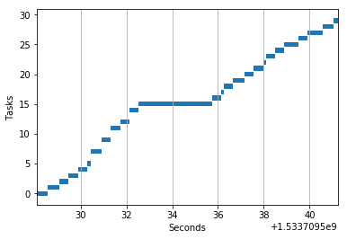

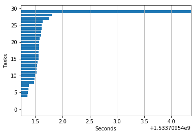

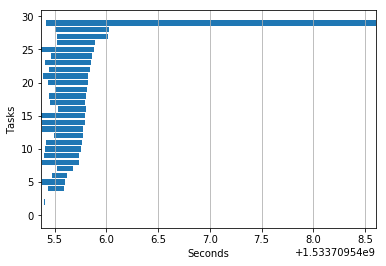

```python
i = random.randint(0, 9000)
graph_demo(address_tuples[i:i+30])
```

That's pretty cool.

When I run it, there are one or two very slow multithreaded and multiprocess tasks which take 5 times longer than the rest. If we ignore these slow tasks, the concurrent code takes about 1/2 second on my machine. While the Synchronous code takes 10 seconds. That a 20x speedup in the best case. A few slow tasks won't be able to slow down our code too much becase the socket connections will time out in a few seconds. Plus, the fast tasks don't have to wait around for the "blocked" tasks in a concurrent environment. This is vital!